# Seventh Week: Generalized Linear Models

Murder or suicide

student name

2018-04-26 20:06:33

> با توجه به سوالات مرگ و میر در آمریکا به سوالات زیر پاسخ دهید.

```r
rm(list = ls())
path = '~/R/HW7/hw_07/'
library(readr)
library(dplyr)
library(highcharter)
library(Hmisc)
library(corrplot)
library(data.table)
library(ROCR)
library(grid)
library(caret)
library(scales)
library(ggplot2)
library(gridExtra)
library(tidyr)
library(h2o)
library(boot)
data = read_csv(paste(path, 'murder_suicide.csv', sep = '/' ))
```

۱. از میان متغیرهای داده مرگ و میر یک زیرمجموعه ایی بدون حشو در نظر بگیرید. ماتریس همبستگی متغیرهای مختلف را به دست آورده و سپس رسم نمایید. علاوه بر این نمودار پراکنش متغیرهای انتخاب شده را همزمان نسبت به هم رسم نمایید.

Code for cleaning data:

```r
data %>% select(-Education1989Revision, -AgeType, -AgeSubstitutionFlag,
                -AgeRecode52, -AgeRecode12, -InfantAgeRecode22, -CurrentDataYear,
                -Race, -BridgedRaceFlag, -RaceImputationFlag, -RaceRecode3, -HispanicOrigin, -HispanicOriginRaceRecode,
                -Icd10Code, -CauseRecode358, -CauseRecode113, -CauseRecode39, -NumberOfEntityAxisConditions,
                -NumberOfRecordAxisConditions, -EducationReportingFlag, -InjuryAtWork, -Age, -PlaceOfInjury) -> data
data %>% mutate(type = MannerOfDeath - 2) -> data
data_numeric = data
for(i in 1:ncol(data_numeric)){
    if(lapply(data_numeric[1, i], class) == "character"){
        data_numeric[,i] = as.numeric(as.factor(as.matrix(data_numeric[,i])))
    }
}
```

Corelation Matrix:

```r
cor_mat_list <- rcorr(as.matrix(data_numeric))
```

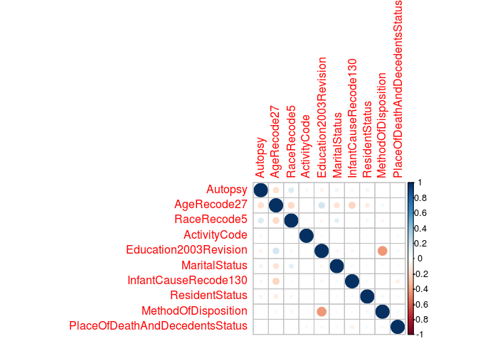

```r
upper_triangle_mat = upper.tri(cor_mat_list$r)

cor_mat_data_frame <- data.frame(var1 = rownames(cor_mat_list$r)[row(cor_mat_list$r)[upper_triangle_mat]],
                                 var2 = rownames(cor_mat_list$r)[col(cor_mat_list$r)[upper_triangle_mat]],
                                 cor = (cor_mat_list$r)[upper_triangle_mat],
                                 p_value = cor_mat_list$P[upper_triangle_mat])



cor_mat_data_frame %>% filter(p_value < 0.05) %>%
    filter(var2 == "type") %>%
    mutate(abs_cor = abs(cor)) %>%
    arrange(-abs_cor) %>% head(10) -> top_ten_vars
data_numeric %>% select(Autopsy, AgeRecode27, RaceRecode5, ActivityCode, Education2003Revision,
                        MaritalStatus, InfantCauseRecode130, ResidentStatus, MethodOfDisposition, PlaceOfDeathAndDecedentsStatus) -> data_numeric
cor(data_numeric) %>% corrplot()
```

Scatterplot:

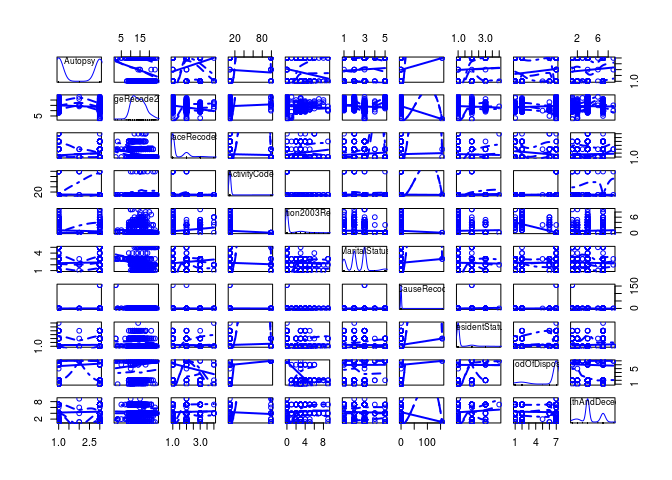

```r
car::scatterplotMatrix(data_numeric[1:1000,])
```

۲. اثر هر یک از متغیرهای جنسیت، نژاد،آموزش، سن و نحوه تدفین را بر مرگ یا خودکشی ارزیابی کنید.

We will perform chisq test of indepencdency:

```r
data %>% select(type, Sex) %>% table %>% chisq.test()
```

```
##
##  Pearson's Chi-squared test with Yates' continuity correction
##
## data:  .
## X-squared = 24.044, df = 1, p-value = 9.417e-07
```

```r
data %>% select(type, RaceRecode5) %>% table %>% chisq.test()
```

```
##
##  Pearson's Chi-squared test
##
## data:  .
## X-squared = 15305, df = 3, p-value < 2.2e-16
```

```r
data %>% select(type, Education2003Revision) %>% table %>% chisq.test()
```

```
##
##  Pearson's Chi-squared test
##
## data:  .
## X-squared = 3572.9, df = 9, p-value < 2.2e-16
```

```r
data %>% select(type, AgeRecode27) %>% table %>% chisq.test()
```

```
##
##  Pearson's Chi-squared test
##
## data:  .
## X-squared = 6761, df = 26, p-value < 2.2e-16
```

```r
data %>% select(type, MethodOfDisposition) %>% table %>% chisq.test()
```

```
##
##  Pearson's Chi-squared test
##
## data:  .
## X-squared = 4460.4, df = 6, p-value < 2.2e-16
```

Since all p-values are smaller than 0.05 we can say that the all of the mentioned variables are effective.

۳. با استفاده از مدل رگرسیون لاجستیک یک مدل به داده ها برازش دهید و سپس آن را نقص یابی کنید.

Since the entries with label 0 are much more than entries with label 1 we omit a random part of first group so both groups are equal. The fitted model:

```r
onesCount = sum(data$type)
data %>% filter(type == 1) -> homi
data %>% filter(type == 0) -> sui
data = rbind(homi, sample_n(sui, onesCount))
fit = glm(type ~ Autopsy +  AgeRecode27 + RaceRecode5 +  ActivityCode + Education2003Revision +
          MaritalStatus + InfantCauseRecode130 + ResidentStatus , data=data, family = "binomial")
summary(fit)
```

```
##
## Call:
## glm(formula = type ~ Autopsy + AgeRecode27 + RaceRecode5 + ActivityCode +
##     Education2003Revision + MaritalStatus + InfantCauseRecode130 +
##     ResidentStatus, family = "binomial", data = data)
##
## Deviance Residuals:
##     Min       1Q   Median       3Q      Max
## -3.3292  -0.8279  -0.0363   0.7700   3.4230
##
## Coefficients:
##                        Estimate Std. Error z value Pr(>|z|)
## (Intercept)           -3.461201   0.125100 -27.668  < 2e-16 ***
## AutopsyU               2.896463   0.114688  25.255  < 2e-16 ***
## AutopsyY               3.844184   0.069476  55.331  < 2e-16 ***
## AgeRecode27           -0.111558   0.005019 -22.229  < 2e-16 ***
## RaceRecode5            0.996279   0.026003  38.314  < 2e-16 ***
## ActivityCode           0.039585   0.001684  23.513  < 2e-16 ***
## Education2003Revision -0.149085   0.007854 -18.981  < 2e-16 ***
## MaritalStatusM        -0.117510   0.042854  -2.742   0.0061 **
## MaritalStatusS         0.384879   0.043703   8.807  < 2e-16 ***
## MaritalStatusU         1.072795   0.133991   8.006 1.18e-15 ***
## MaritalStatusW         0.379594   0.073579   5.159 2.48e-07 ***
## InfantCauseRecode130   0.104712   1.071156   0.098   0.9221
## ResidentStatus         0.160703   0.024846   6.468 9.94e-11 ***
## ---
## Signif. codes:  0 '***' 0.001 '**' 0.01 '*' 0.05 '.' 0.1 ' ' 1
##
## (Dispersion parameter for binomial family taken to be 1)
##
##     Null deviance: 46690  on 33679  degrees of freedom
## Residual deviance: 30558  on 33667  degrees of freedom
## AIC: 30584
##
## Number of Fisher Scoring iterations: 15
```

P-value of variable InfantCauseRecode130 is higher than 0.05 so we omit it from the model:

```r
fit = glm(type ~ Autopsy +  AgeRecode27 + RaceRecode5 +  ActivityCode + Education2003Revision +
              MaritalStatus  + ResidentStatus , data=data, family = "binomial")
summary(fit)
```

```
##
## Call:
## glm(formula = type ~ Autopsy + AgeRecode27 + RaceRecode5 + ActivityCode +
##     Education2003Revision + MaritalStatus + ResidentStatus, family = "binomial",
##     data = data)
##
## Deviance Residuals:
##     Min       1Q   Median       3Q      Max
## -3.3388  -0.8257  -0.0233   0.7683   3.4348
##
## Coefficients:
##                        Estimate Std. Error z value Pr(>|z|)
## (Intercept)           -3.357299   0.123719 -27.136  < 2e-16 ***
## AutopsyU               2.900517   0.114407  25.353  < 2e-16 ***
## AutopsyY               3.844548   0.069272  55.499  < 2e-16 ***
## AgeRecode27           -0.118414   0.004905 -24.144  < 2e-16 ***
## RaceRecode5            0.991553   0.025965  38.187  < 2e-16 ***
## ActivityCode           0.039664   0.001686  23.532  < 2e-16 ***
## Education2003Revision -0.147449   0.007796 -18.914  < 2e-16 ***
## MaritalStatusM        -0.120701   0.042899  -2.814   0.0049 **
## MaritalStatusS         0.370286   0.043677   8.478  < 2e-16 ***
## MaritalStatusU         1.068769   0.134125   7.968 1.61e-15 ***
## MaritalStatusW         0.402557   0.073592   5.470 4.50e-08 ***
## ResidentStatus         0.163220   0.024818   6.577 4.81e-11 ***
## ---
## Signif. codes:  0 '***' 0.001 '**' 0.01 '*' 0.05 '.' 0.1 ' ' 1
##
## (Dispersion parameter for binomial family taken to be 1)
##
##     Null deviance: 46690  on 33679  degrees of freedom
## Residual deviance: 30621  on 33668  degrees of freedom
## AIC: 30645
##
## Number of Fisher Scoring iterations: 6
```

We can see diagnostic plots for glm below:

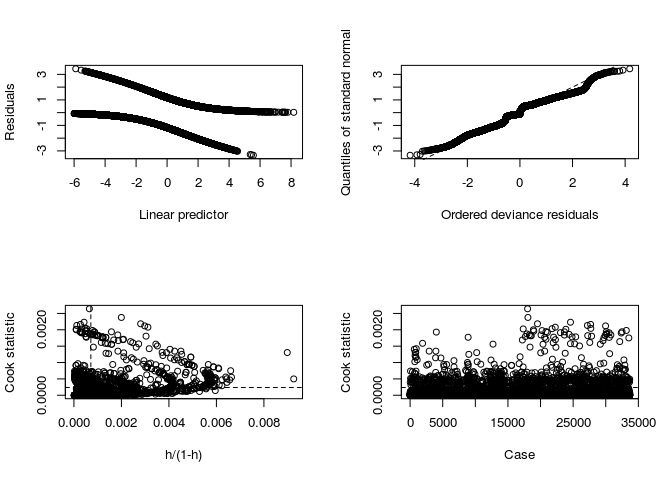

```r
glm.diag.plots(fit, glmdiag = glm.diag(fit))
```

We can see from the plots that the model is good.

۴. با استفاده از سه نمودار خروجی مدل را نسبت به داده واقعی ارزیابی کنید.

Below we can see density plot of positive and negative labeled enteries prediction:

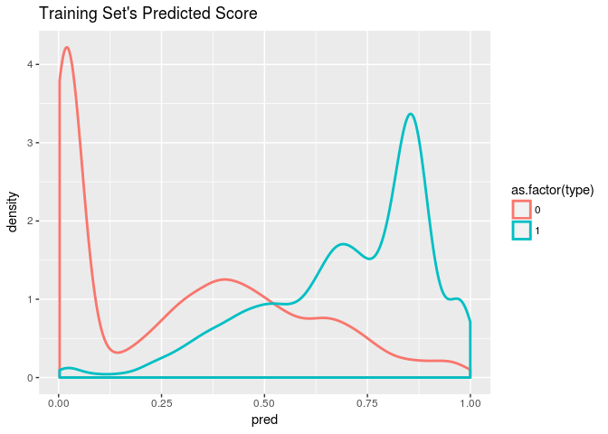

```r
data$pred = predict.glm(fit, data, type = "response")
ggplot(data, aes(pred, color = as.factor(type))) + geom_density(size=1) + ggtitle( "Training Set's Predicted Score" )
```

It is depicted in above figure that denisty peak of negative predictions are in left part and the positive peak is in the right part so model is good. Below we can see confusion table:

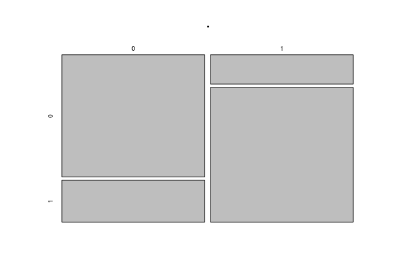

```r
table(data$type,ifelse(fitted(fit)>0.5,1,0)) %>% plot()
```

Area of 0-0 square and 1-1 square is relatively large so we can conclude that model is good.

۵. ابتدا ۲۰ درصد داده را به صورت تصادفی به عنوان تست در نظر بگیرید. مدل را با استفاده از ۸۰ درصد باقی مانده برازش دهید. با استفاده از پارامتر قطع ۰.۵ نتایج را برای داده تست پیش بینی کنید. سپس کمیت های زیر را محاسبه کنید.

- P: positive samples
- N: negative samples
- TP: true positive TP (eqv. with hit)
- TN: true negative (eqv. with correct rejection)
- FP: false positive (eqv. with false alarm, Type I error)
- FN: false negative (eqv. with miss, Type II error)
- Accuracy (ACC) ACC = (TP+TN)/(P+T)
- False positive rate (FPR): 1- TN/N
- True positive rate (TPR): TP/P

مشابه آنچه در کلاس گفته شد نمایشی از چهار کمیت TN, TP,FP,FN به همراه داده ها رسم نمایید.

```r
idx = c(1:33680)
trainIdx = sample(idx, size = 0.8*33680)
testIdx = setdiff(idx, trainIdx)
train = data[trainIdx,]
test = data[testIdx,]
fit = glm(type ~ Autopsy +  AgeRecode27 + RaceRecode5 +  ActivityCode + Education2003Revision +
             MaritalStatus  + ResidentStatus , data=train, family = "binomial")
test$pred = predict.glm(fit, test, type="response")
test %>% select(type, pred) -> res
res %>% mutate(pred = (pred > 0.5)) -> res
P = sum(res$type == 1)
print(P)
```

```
## [1] 3344
```

```r
N = sum(res$type == 0)
print(N)
```

```
## [1] 3392
```

```r
TP = sum((res$type == res$pred & res$pred == 1))
print(TP)
```

```
## [1] 2760
```

```r
TN = sum((res$type == res$pred & res$pred == 0))
print(TN)
```

```
## [1] 2541
```

```r
FP = sum((res$type != res$pred & res$pred == 1))
print(FP)
```

```
## [1] 851
```

```r
FN = sum((res$type != res$pred & res$pred == 0))
print(FN)
```

```
## [1] 584
```

```r
acc = (TP + TN)/(P+N)
print(acc)
```

```
## [1] 0.7869656
```

```r
FPR = 1 - TN/N
print(FPR)
```

```
## [1] 0.2508844
```

```r
TPR = TP/P
print(TPR)
```

```
## [1] 0.8253589
```

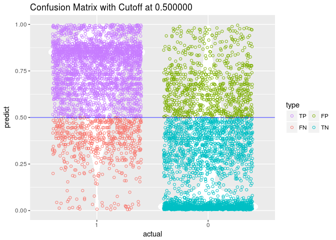

```r
ConfusionMatrixInfo <- function( data, predict, actual, cutoff )
{
    # extract the column ;
    # relevel making 1 appears on the more commonly seen position in
    # a two by two confusion matrix
    predict <- data[[predict]]
    actual  <- relevel( as.factor( data[[actual]] ), "1" )

    result <- data.table( actual = actual, predict = predict )

    # caculating each pred falls into which category for the confusion matrix
    result[ , type := ifelse( predict >= cutoff & actual == 1, "TP",
                              ifelse( predict >= cutoff & actual == 0, "FP",
                                      ifelse( predict <  cutoff & actual == 1, "FN", "TN" ) ) ) %>% as.factor() ]

    # jittering : can spread the points along the x axis
    plot <- ggplot( result, aes( actual, predict, color = type ) ) +
        geom_violin( fill = "white", color = NA ) +
        geom_jitter( shape = 1 ) +
        geom_hline( yintercept = cutoff, color = "blue", alpha = 0.6 ) +
        scale_y_continuous( limits = c( 0, 1 ) ) +
        scale_color_discrete( breaks = c( "TP", "FN", "FP", "TN" ) ) + # ordering of the legend
        guides( col = guide_legend( nrow = 2 ) ) + # adjust the legend to have two rows
        ggtitle( sprintf( "Confusion Matrix with Cutoff at %f", cutoff ) )

    return( list( data = result, plot = plot ) )
}

cm_info = ConfusionMatrixInfo( data = test, predict = "pred", actual = "type", cutoff = .5 )
cm_info$plot
```

۶. نمودار صحت مدل (accuracy) را بر حسب مقادیر مختلف قطع برای داده تست رسم نمایید. کدام پارامتر قطع بالاترین صحت را در پیش بینی داراست؟

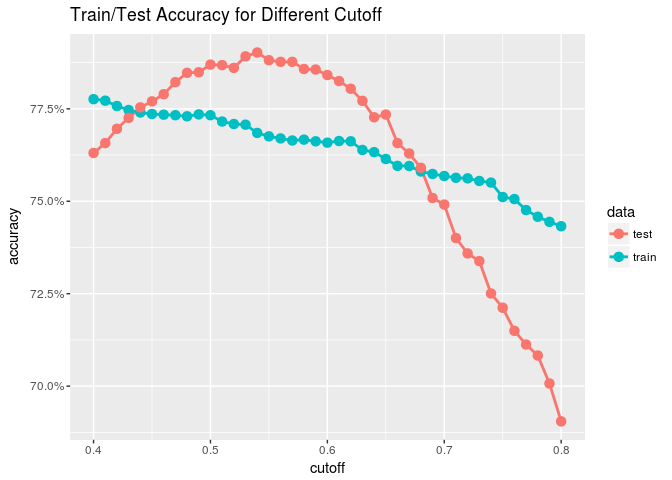

```r
AccuracyCutoffInfo <- function( train, test, predict, actual )
{
    # change the cutoff value's range as you please
    cutoff <- seq( .4, .8, by = .01 )

    accuracy <- lapply( cutoff, function(c)
    {
        # use the confusionMatrix from the caret package
        cm_train <- confusionMatrix( as.factor(as.numeric( train[[predict]] > c )), as.factor(train[[actual]]) )
        cm_test  <- confusionMatrix( as.factor(as.numeric( test[[predict]]  > c )), as.factor(test[[actual]])  )

        dt <- data.table( cutoff = c,
                          train  = cm_train$overall[["Accuracy"]],
                          test   = cm_test$overall[["Accuracy"]] )
        return(dt)
    }) %>% rbindlist()

    # visualize the accuracy of the train and test set for different cutoff value
    # accuracy in percentage.
    accuracy_long <- gather( accuracy, "data", "accuracy", -1 )

    plot <- ggplot( accuracy_long, aes( cutoff, accuracy, group = data, color = data ) ) +
        geom_line( size = 1 ) + geom_point( size = 3 ) +
        scale_y_continuous( label = percent ) +
        ggtitle( "Train/Test Accuracy for Different Cutoff" )

    return( list( data = accuracy, plot = plot ) )
}
train$pred = predict.glm(fit, train)
accuracy_info = AccuracyCutoffInfo( train %>% select(pred, type), test %>% select(pred, type), predict = "pred", actual = "type" )
accuracy_info$plot
```

We can see from the figure above that best cutoff value is around 0.53.

۷. نمودار ROC را برای داده های قسمت قبل رسم نمایید. همچنین نقطه مربوط به بهترین پارامتر قطع را مشخص نمایید.

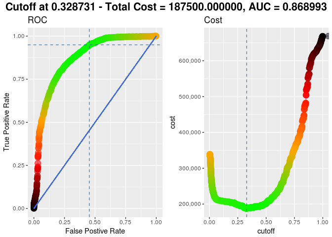

```r
ROCInfo <- function( data, predict, actual, cost.fp, cost.fn )
{
    # calculate the values using the ROCR library
    # true positive, false postive
    pred <- prediction( data[[predict]], data[[actual]] )
    perf <- performance( pred, "tpr", "fpr" )
    roc_dt <- data.frame( fpr = perf@x.values[[1]], tpr = perf@y.values[[1]] )

    # cost with the specified false positive and false negative cost
    # false postive rate * number of negative instances * false positive cost +
    # false negative rate * number of positive instances * false negative cost
    cost <- perf@x.values[[1]] * cost.fp * sum( data[[actual]] == 0 ) +
        ( 1 - perf@y.values[[1]] ) * cost.fn * sum( data[[actual]] == 1 )

    cost_dt <- data.frame( cutoff = pred@cutoffs[[1]], cost = cost )

    # optimal cutoff value, and the corresponding true positive and false positive rate
    best_index  <- which.min(cost)
    best_cost   <- cost_dt[ best_index, "cost" ]
    best_tpr    <- roc_dt[ best_index, "tpr" ]
    best_fpr    <- roc_dt[ best_index, "fpr" ]
    best_cutoff <- pred@cutoffs[[1]][ best_index ]

    # area under the curve
    auc <- performance( pred, "auc" )@y.values[[1]]

    # normalize the cost to assign colors to 1
    normalize <- function(v) ( v - min(v) ) / diff( range(v) )

    # create color from a palette to assign to the 100 generated threshold between 0 ~ 1
    # then normalize each cost and assign colors to it, the higher the blacker
    # don't times it by 100, there will be 0 in the vector
    col_ramp <- colorRampPalette( c( "green", "orange", "red", "black" ) )(100)
    col_by_cost <- col_ramp[ ceiling( normalize(cost) * 99 ) + 1 ]

    roc_plot <- ggplot( roc_dt, aes( fpr, tpr ) ) +
        geom_line( color = rgb( 0, 0, 1, alpha = 0.3 ) ) +
        geom_point( color = col_by_cost, size = 4, alpha = 0.2 ) +
        geom_segment( aes( x = 0, y = 0, xend = 1, yend = 1 ), alpha = 0.8, color = "royalblue" ) +
        labs( title = "ROC", x = "False Postive Rate", y = "True Positive Rate" ) +
        geom_hline( yintercept = best_tpr, alpha = 0.8, linetype = "dashed", color = "steelblue4" ) +
        geom_vline( xintercept = best_fpr, alpha = 0.8, linetype = "dashed", color = "steelblue4" )

    cost_plot <- ggplot( cost_dt, aes( cutoff, cost ) ) +
        geom_line( color = "blue", alpha = 0.5 ) +
        geom_point( color = col_by_cost, size = 4, alpha = 0.5 ) +
        ggtitle( "Cost" ) +
        scale_y_continuous( labels = comma ) +
        geom_vline( xintercept = best_cutoff, alpha = 0.8, linetype = "dashed", color = "steelblue4" )

    # the main title for the two arranged plot
    sub_title <- sprintf( "Cutoff at %f - Total Cost = %f, AUC = %f",
                          best_cutoff, best_cost, auc )

    # arranged into a side by side plot
    plot <- arrangeGrob( roc_plot, cost_plot, ncol = 2,
                         top = textGrob( sub_title, gp = gpar( fontsize = 16, fontface = "bold" ) ) )

    return( list( plot        = plot,
                  cutoff      = best_cutoff,
                  totalcost   = best_cost,
                  auc         = auc,
                  sensitivity = best_tpr,
                  specificity = 1 - best_fpr ) )
}
cost_fp = 100
cost_fn = 200
roc_info = ROCInfo( data = test %>% select(pred, type), predict = "pred",
                    actual = "type", cost.fp = cost_fp, cost.fn = cost_fn )
grid.draw(roc_info$plot)
```

False negative is much important than false positive because if we detect a suicide as homicide nothing important happens but if we detect a homicide as a suicide the killer gets away. So the cost of false negative is set twice the cost of false positive. The best cutoff value in this scenario is around 0.3.

۸. با قرار دادن کمیت nfolds = 5 و با استفاده از H20 مدل مساله را بسازید و نتیجه حاصل را ارزیابی کنید.

```r
h2o.init()
```

```
##  Connection successful!
##
## R is connected to the H2O cluster:
##     H2O cluster uptime:         2 hours 28 minutes
##     H2O cluster version:        3.16.0.2
##     H2O cluster version age:    4 months and 27 days !!!
##     H2O cluster name:           H2O_started_from_R_erfan_rmn501
##     H2O cluster total nodes:    1
##     H2O cluster total memory:   1.47 GB
##     H2O cluster total cores:    8
##     H2O cluster allowed cores:  8
##     H2O cluster healthy:        TRUE
##     H2O Connection ip:          localhost
##     H2O Connection port:        54321
##     H2O Connection proxy:       NA
##     H2O Internal Security:      FALSE
##     H2O API Extensions:         XGBoost, Algos, AutoML, Core V3, Core V4
##     R Version:                  R version 3.4.2 (2017-09-28)
```

```r
hdata = as.h2o(data)
chglm = h2o.glm(y = "type", x= c("Autopsy",  "AgeRecode27", "RaceRecode5",  "ActivityCode", "Education2003Revision",
                                     "MaritalStatus", "ResidentStatus"), training_frame = hdata, family="binomial",nfolds = 5)
chglm
```

```
## Model Details:
## ==============
##
## H2OBinomialModel: glm
## Model ID:  GLM_model_R_1524739115446_37
## GLM Model: summary
##     family  link                                regularization
## 1 binomial logit Elastic Net (alpha = 0.5, lambda = 3.392E-4 )
##   number_of_predictors_total number_of_active_predictors
## 1                          5                           5
##   number_of_iterations training_frame
## 1                    4           data
##
## Coefficients: glm coefficients
##                   names coefficients standardized_coefficients
## 1             Intercept     0.588465                  0.048557
## 2        ResidentStatus     0.208331                  0.117753
## 3 Education2003Revision    -0.139545                 -0.262192
## 4           AgeRecode27    -0.159297                 -0.625322
## 5          ActivityCode     0.029429                  0.454175
## 6           RaceRecode5     1.088059                  0.691426
##
## H2OBinomialMetrics: glm
## ** Reported on training data. **
##
## MSE:  0.1888667
## RMSE:  0.4345879
## LogLoss:  0.570659
## Mean Per-Class Error:  0.2890439
## AUC:  0.7868844
## Gini:  0.5737687
## R^2:  0.2445334
## Residual Deviance:  38439.59
## AIC:  38451.59
##
## Confusion Matrix (vertical: actual; across: predicted) for F1-optimal threshold:
##            0     1    Error         Rate
## 0      10225  6615 0.392815  =6615/16840
## 1       3120 13720 0.185273  =3120/16840
## Totals 13345 20335 0.289044  =9735/33680
```

[output cut: 64 more lines]

```
## ---
##                         mean           sd cv_1_valid cv_2_valid cv_3_valid
## precision          0.6763457  0.012279668   0.647868   0.673785  0.6789257
## r2                0.24439728 0.0026854665  0.2444182 0.23933472  0.2465075
## recall             0.8155917  0.017271856 0.85197467 0.81285167 0.81640965
## residual_deviance   7688.985    87.494736  7583.2305  7740.5073  7772.5527
## rmse               0.4346146  7.787268E-4 0.43462044  0.4360806 0.43401405
## specificity       0.60778713   0.03158644 0.53846157  0.6062222 0.60993534
##                   cv_4_valid cv_5_valid
## precision         0.70238096 0.67876893
## r2                0.25020683 0.24151917
## recall             0.7753667  0.8213558
## residual_deviance   7508.032  7840.6006
## rmse              0.43291903  0.4354388
## specificity        0.6795827  0.6047337
```

۹. آیا ما میتوانیم سرویسی به قضات ارایه کنیم تا با استفاده از اطلاعات مرگ بتوانند موارد مشکوک به قتل را از خودکشی تفکیک دهند؟

Because of the same reason stated in question 7, it is very important for the decision making system to avoid false negatives. The model we developed has a false negative to negative ratio of about 17% which means from each 100 cases 17 killers get away without getting justice they deserved. So the presence of a judge for making more accurate decisions is absolutely essential.